# Introduction to Git and version control

03 March 2016

## Why using version control ?

## Organise you scripts

- keep previous versions without multiple unmanageable copies and folders
- experiment new ideas BUT easy to come back to the previous version
- develop versions in parallel

## Save your scripts

- save each version and each change with minimal disk space
- synchronise with a web repository (like dropbox)

## Share your scripts

- using online repositories
- synchronise between labtops
- make your scripts available for all

## Git is made for plain text

- git only records the part of the text that changes between 2 versions
- git makes a copy each time for binary files (incl. word)
- you should avoid including to much data, outputs, images

## Git is not the only one

- SVN, CVS (centralized)
- Mercurial, Baazar (distributed, like git)

## Starting with git

## Install

- intall Git language (win .exe / OSX installer / Linux apt-get)
- then configurate

  ```
  git config --global user.name "my name"
  git config --global user.email "my@email.com"
  ```

## Start a project in your computer

```
cd yourFolder
git init
git add --all (or add specific files)
git commit -m 'initial version'
```

## Tracked and untracked files

- you can add a file to track using git add
- you may choose to not track all files in your folder (big data…)
- create a .gitignore file with for instance

  ```
  data/*
  *.Rdata
  *.Rapp.history
  .DS_Store
  ```

- untrack a file without deleting it

  ```
  git rm --cached filename
  ```

## Remote servers

## GitHub

offers free public repositories (anyone can see it), free private repositories for academics, and private paid accounts

- created in 2008 following the ideology of free/open software
- is used a lot for sharing and collaborative working (public -> anyone can propose a modification)
- a wiki an a webpage for each repository you create
- gitHub for Academics ? http://blogs.lse.ac.uk/impactofsocialsciences/2013/06/04/github-for-academics/
- making your code citable ? https://guides.github.com/activities/citable-code/

## Bitbucket

[figure not shown]

Bitbucket offers free private repositories for a maximum of 5 collaborators, as well as public repositories and public wiki

- created in 2010 but uses git since 2011
- commercial

## Synchronize your git folder

- first time: create a remote repository
1. go to bitbucket or github, create a new repo
2. copy the address of the repo (.git)
3. go to your terminal

   ```
   cd yourFolder
   git remote add origin https://someadress.git
   git push -u origin master --all
   ```

- next times 2 commands are necessary

  ```
  git pull (download)
  git push (upload)
  ```

## Clone an existing project from a repository

- find the address (.git) on the web page of the repository
- then open a terminal and

  ```
  git clone git://something.git
  ```

## How to use it then ?

- First, if you work on several computers or people

  ```
  git pull
  ```

- Several times a day

  ```
  git add --all (or selected files)
  git commit -m "comment on the changes you did"
  ```

- At the end of the day

  ```
  git push
  ```

- other commands to see where you are

  ```
  git status
  git log
  ```

## The magic of branches

## What is a branch ?

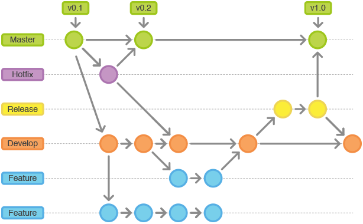

The first defaut branch is named *master*

## How to do, the basics

- create and switch to new local branch

  ```
  git checkout -b newbranch
  ```

- navigate between local branches

  ```
  git checkout branch2go
  ```

- delete a local branch

  ```
  git branch -d branch2delete
  ```

## Merging two branches

Merge modify the receiver branch but not the source branch

- checkout (go to) the receiver branch and

  ```
  git merge branch2merge
  ```

  ```
  git merge --no-ff branch2merge
  ```

## Merging two branches: case fast-forward

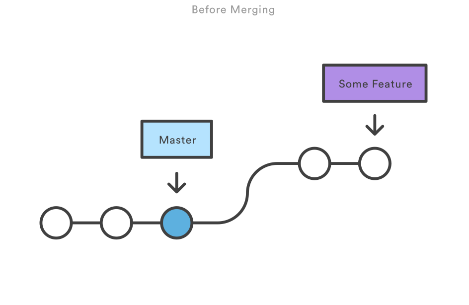

## Merging two branches: case fast-forward

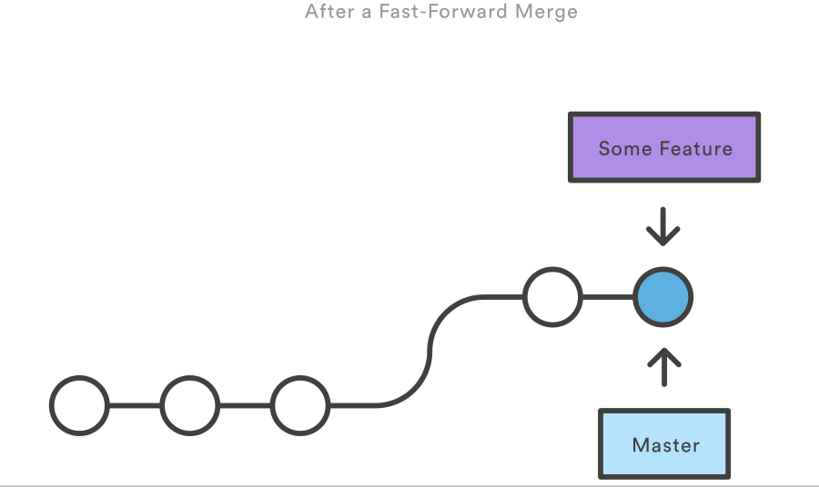

## Merging two branches: case 3-ways merge

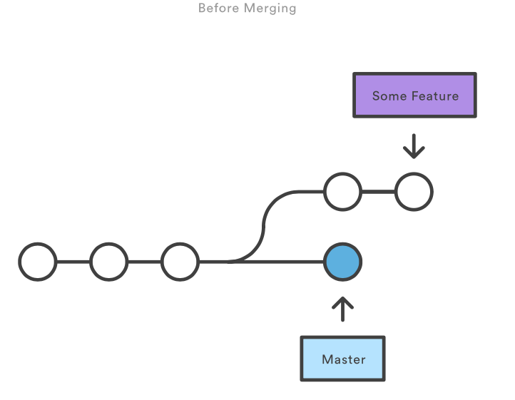

## Merging two branches: case 3-ways merge

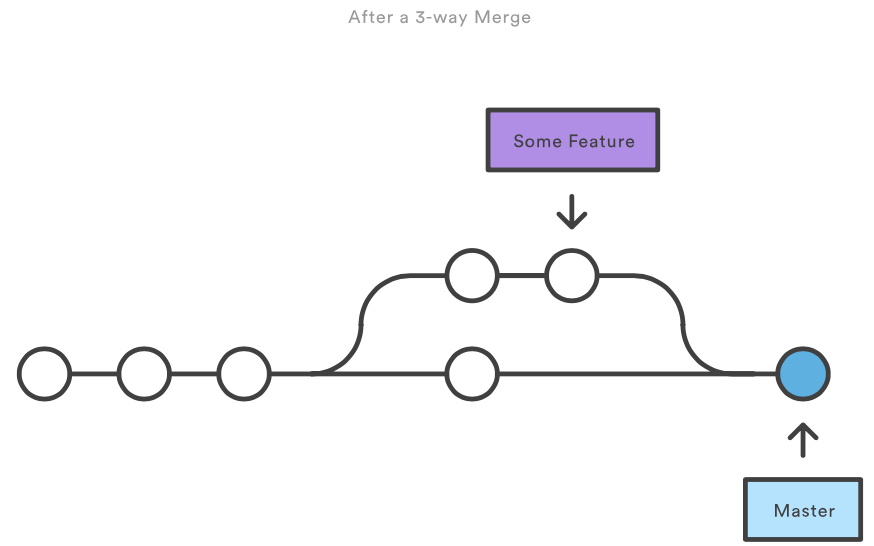

## Solving merge problems

In a 3-ways case, if the same file (part of file) has been modified, there will be conflits.

```
# On branch master
# Unmerged paths:
# (use "git add/rm ..." as appropriate to mark resolution)
#
# both modified: script.r
```

- fix the conflict (open the problematic file and choose the version of code you want to keep)
- run `git add` for the file you modified
- then `git commit` : you should have a message saying you resolved the conflict

## Solving merge problems

before conflict solved

```r
rm(list=ls())
<<<<<<< HEAD
    x=24 # new version (source branch)
=======
    x=10 # old version (receiver branch, here master)
>>>>>>> master
print(x^2)
```

after conflict solved

```r
rm(list=ls())
x=24 # new version (source branch)
print(x^2)
```

## Rebase

[figure not shown]

## Rebase

Alternative to merging if the source branch is local only (no copy on remote). The history of the branch you rebase will be changed.

- checkout the branch you want to rebase/move (ie. new feature for instance)

  ```
  git rebase baseBranch
  ```

## Branches and remote repository

- create a branch locally that is in the server

  ```
  git checkout -b branchname origin/branchname
  ```

- create a branch that is only local on the remote server

  ```
  git push -u origine mylocalbranch
  ```

- delete remote branch

  ```
  git push origin --delete branch2delete
  ```

- upload/dowload changes

  ```
  git pull origin thebranch
  git push origin thebranch
  ```

## Branches and remote repository

- get all remote branches and changes that have been pushed from others and are not local yet

  ```
  git fetch --all
  ```

- remove local dangling branches (i.e., remote tracking branch has been deleted)

  ```
  git fetch --prune
  ```

- `git pull` is a combinaison of `git fetch` and `git merge` : if there are merging conflicts when using `git pull` do it in 2 steps to keep control on the merge!

## Navigation between versions

## Navigation between commits

- Go to a specific state (commit)

  ```
  git log
  git checkout commitRef
  ```

- Revert changes made at a commit

  ```
  git log
  git revert commitRef
  ```

- Return to the last commit AND keep tack of this

  ```
  git revert HEAD
  ```

## Navigation between commits

- You can go to second last using ^ or other previous using~

  ```
  git revert HEAD^
  git revert HEAD~2
  ```

- Go back to last(s) commit (all modifications will be lost)

  ```
  git reset --hard HEAD
  git reset --hard HEAD^
  ```

- Go back to last commit for one specific file (modifications lost)

  ```
  git checkout -- filename
  ```

## Additional useful commands

- tag a commit

  ```
  git tag
  git tag -a commitName -m "version XX"
  ```

- overwrite/add one file of the source branch into the current branch

  ```
  git checkout branch sourcebranch filename
  ```

## More about git commands

1. Nice tutos https://www.atlassian.com/git/tutorials
2. Just Google it!
- a lot of forums
- a lot of tutorials online
- a lot of information and help

## Are you bothered about using command lines ?

## SourceTree

- A magic tool…